# Lecture 4

pronak@business.rutgers.edu

9/25/2022

## Forecasting Methods

### Naive Method

- Called the “no-change” forecast
- Serves as a good “benchmark”
- Limited to ingenuity of the forecaster

$$\begin{aligned}
\hat{Y}_{t+1} = Y_t \\
\hat{Y}_{t+1} = Y_t + |Y_t - Y_{t-1}| \\
\hat{Y}_{t+1} = Y_t * \frac{Y_t}{Y_{t-1}} \\
\hat{Y}_{t+1} = Y_{t-3}
\end{aligned}$$

### Averages

- Average of past observation
- Forecast can decide the weights and past observations that goes into the forecast
- Inexpensive way to update daily,weekly, or short-term forecast

#### Simple Average assigned equal weight to all observations

$$\begin{aligned}
\hat{Y}_{t+1} = \frac{\sum_{i=i}^{t}Y_i}{t} \\
\hat{Y}_{t+2} = \frac{(t*\hat{Y}_{t})+Y_{t+1}}{t+1}
\end{aligned}$$

#### Moving Average

- Assigns equal weight to few observations
- Does not handle seasonality well
- MA(k) is Moving Average of order k, where k observations are part of the forecast model
- The smaller the k, the larger the weight given to recent period
- A small k is most desirable when there are sudden shifts
- A large k is desirable when there are wide infrequent fluctuations
- The larger the order, the greater the smoothing effect

$$\hat{Y}_{t+1} = \frac{\sum_{i=t-k+1}^{t}Y_i}{k}$$

#### Double Moving Average

- Accounts for Trends

$$\begin{aligned}
\hat{Y}_{t+p} = A_t + B_t*p \\
A_t = M_t +(M_t - \hat{M}_t) = 2M_t - \hat{M}_t \\
B_t = \frac{2}{k-1}*(M-t - \hat{M}_t) \\
\hat{M}_t = \frac{\sum_{i=t-k+1}^{t}M_i}{k} \\
M_t = \hat{Y}_{t-1} = \frac{\sum_{i=t-k+1}^{t}Y_i}{k}
\end{aligned}$$

### Exponential Smoothing

- Best for short-term forecast where there is no predictable upwards or downwards trend.
- Idea is to estimate the current level and revise estimate was more recent data comes in.
- The weight of alpha is assigned to the recent observation
- the weight decreases exponentially for observations in the past

$$\begin{aligned}
\hat{Y}_{t+1} = \alpha Y_t + \alpha (1 - \alpha)Y_{t-1}+ \alpha (1-
\alpha )^2 Y_{t-2} + \dots \\
\hat{Y}_{t+1} = \alpha Y_t + (1 - \alpha) \hat{Y}_{t} \\
\hat{Y}_{t+1} = \alpha Y_t + (Y_{t} - \hat{Y}_{t})
\end{aligned}$$

### Holt

- Used for data with trend
- It called **double exponential smoothing** since we have to estimate current level and slope for trend

$$\begin{aligned}
\hat{Y}_{t+p} = l_t + \rho * T_t \\
l_t = \alpha Y_t + (1 - \alpha) (l_{t-1} + T_{t-1}) \\
T_{t} = \beta (l_t - l_{t-1}) + (1 - \beta)T_{t-1}
\end{aligned}$$

### Winters

- Builds on Holt’s equation by accounting for seasonality
- There are three equation to account for level, trend, and seasonality.

$$\begin{aligned}
\hat{Y}_{t+p} = (l_t * \rho * T_t) * S_{t-s+p} \\
l_t = \alpha \frac{Y_t}{S_{t-s}} + (1 - \alpha) (l_{t-1} + T_{t-1}) \\
T_{t} = \beta (l_t - l_{t-1}) + (1 - \beta)T_{t-1} \\
S_{t-s+ \rho} = \gamma \frac{Y_t}{l_t} + ( 1 - \gamma)S_{t-s}
\end{aligned}$$

```r
library(fpp)
library(fpp2)
library(TTR)

attributes(elecequip)
```

```
## $tsp
## [1] 1996.000 2012.167   12.000
##
## $class
## [1] "ts"
```

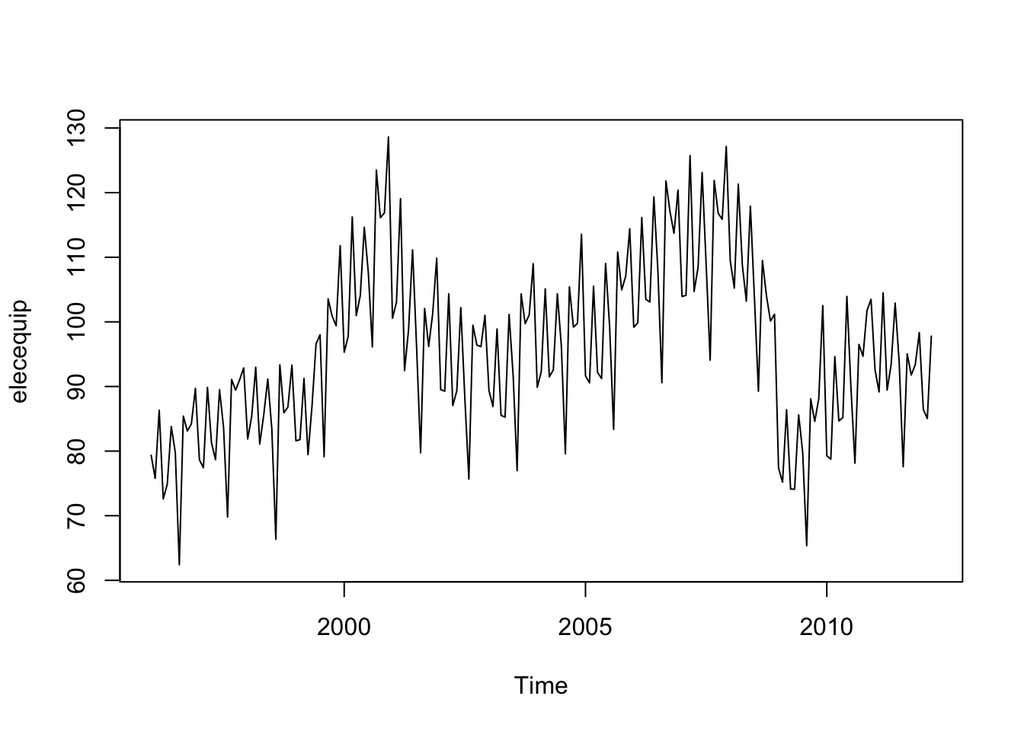

```r
plot(elecequip)
```

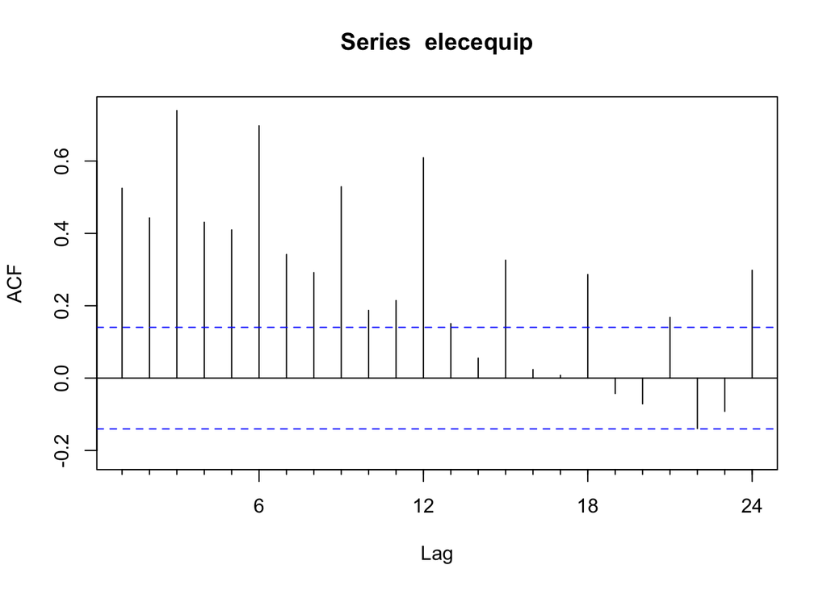

```r
Acf(elecequip)
```

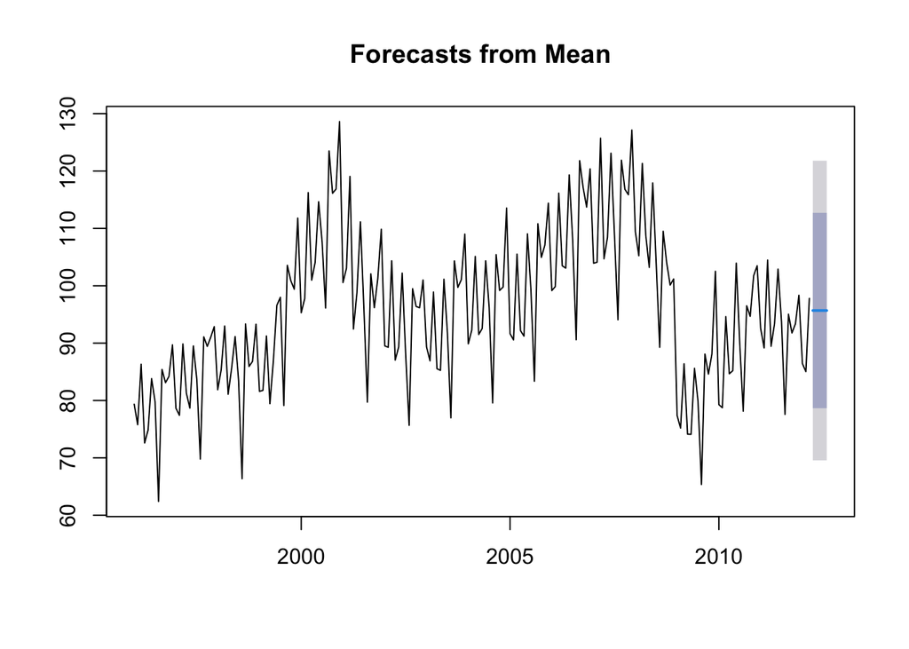

```r
#take Mean of all available history

mean_forecast <- meanf(elecequip,5)
plot(mean_forecast)
```

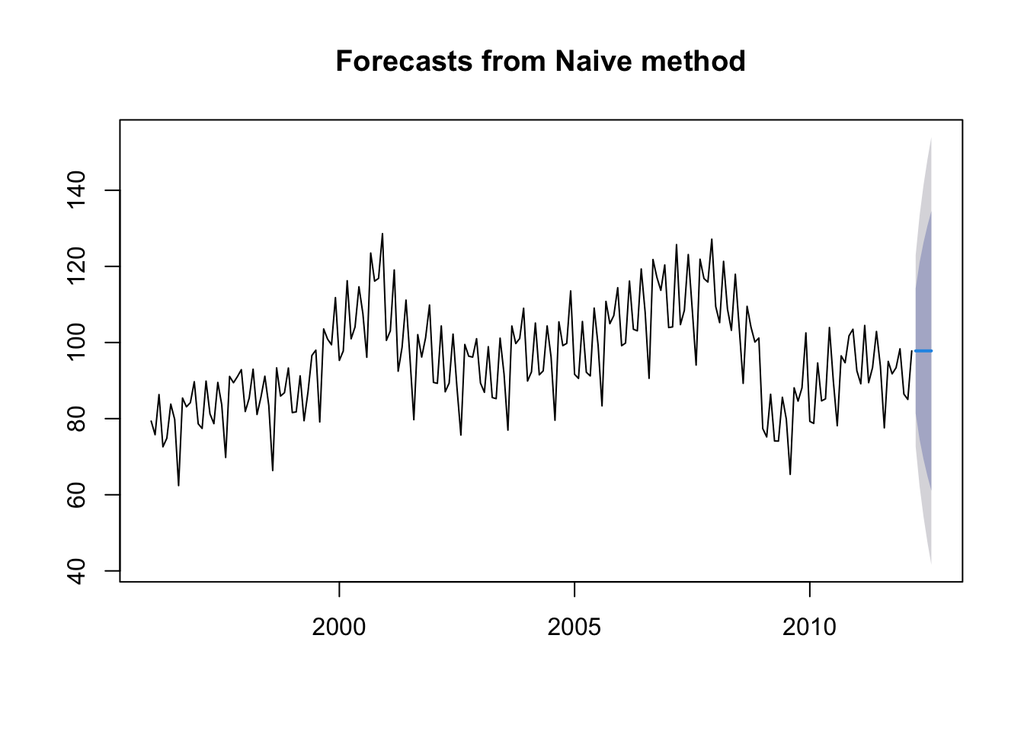

```r
# Naive
naive_forecast <- naive(elecequip,5)
plot(naive_forecast)
```

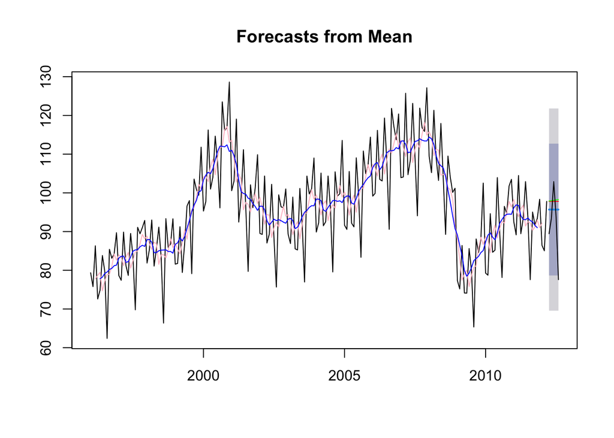

```r
# Random Walk
rwf_forecast <- rwf(elecequip,5)
rwf_forecast <- rwf(elecequip,5, drift=TRUE)
# Seasonal Naive
snaive_forecast <- snaive(elecequip,5)

# Moving Averages

MA5_forecast <- ma(elecequip,order=5)
MA9_forecast <- ma(elecequip,order=9)

# plot all in a single chart
plot(mean_forecast)
lines(naive_forecast$mean,col="red")
lines(rwf_forecast$mean,col="green")
lines(snaive_forecast$mean,col="black")
lines(MA5_forecast,col="Pink")
lines(MA9_forecast,col="Blue")
```

```r
# what other attributes are there?
attributes(naive_forecast)
```

```
## $names
##  [1] "method"    "model"     "lambda"    "x"         "fitted"    "residuals"
##  [7] "series"    "mean"      "level"     "lower"     "upper"
##
## $class
## [1] "forecast"
```

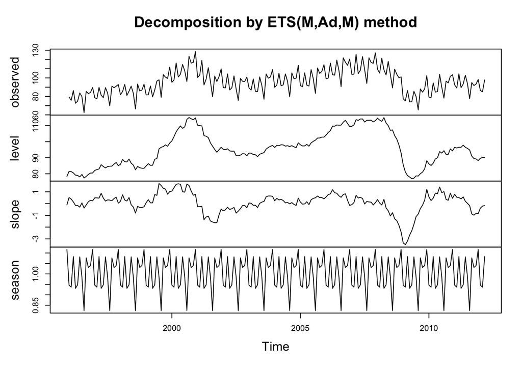

```r
# Decomposition
ets_forecast <- ets(elecequip)
plot(ets_forecast)
```

```r
attributes(ets_forecast)
```

```
## $names
##  [1] "loglik"     "aic"        "bic"        "aicc"       "mse"
##  [6] "amse"       "fit"        "residuals"  "fitted"     "states"
## [11] "par"        "m"          "method"     "series"     "components"
## [16] "call"       "initstate"  "sigma2"     "x"
##
## $class
## [1] "ets"
```

```r
ets_forecast$mse
```

```
## [1] 9.617265
```

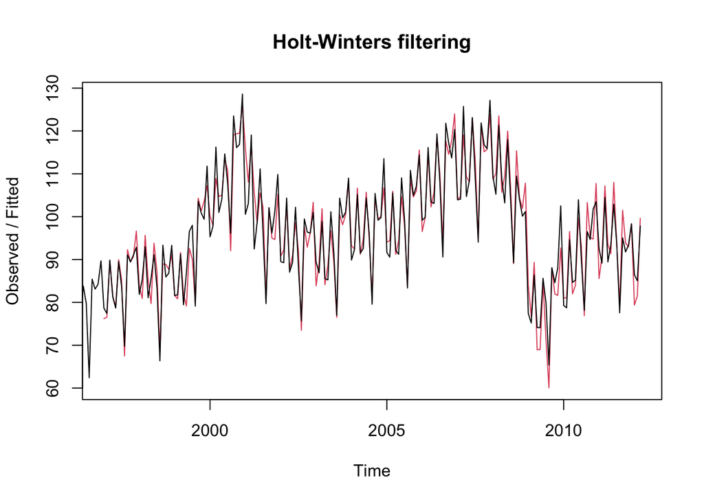

```r
# HoltWinters
HW_forecast <- HoltWinters(elecequip)
plot(HW_forecast)
```

```r
SSE_Simple <- HoltWinters(elecequip,beta=FALSE,gamma=FALSE)
attributes(SSE_Simple)
```

```
## $names
## [1] "fitted"       "x"            "alpha"        "beta"         "gamma"
## [6] "coefficients" "seasonal"     "SSE"          "call"
##
## $class
## [1] "HoltWinters"
```

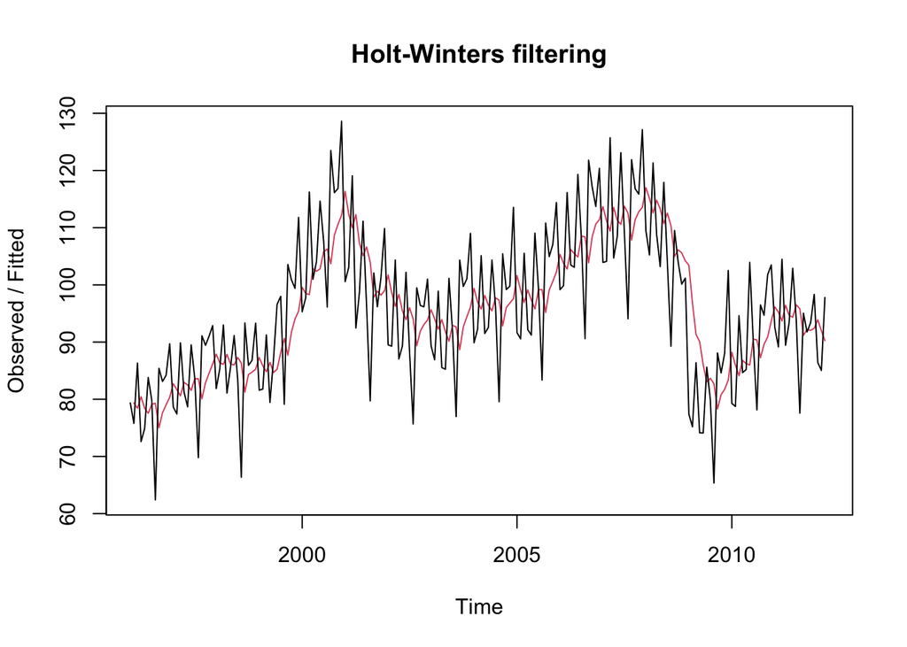

```r
plot(SSE_Simple)
```

```r
SSE_Simple$SSE
```

```
## [1] 18961.1
```

```r
head(SSE_Simple$fitted)
```

```
##              xhat    level
## Feb 1996 79.35000 79.35000
## Mar 1996 78.44473 78.44473
## Apr 1996 80.44171 80.44171
## May 1996 78.45324 78.45324
## Jun 1996 77.54208 77.54208
## Jul 1996 79.13148 79.13148
```

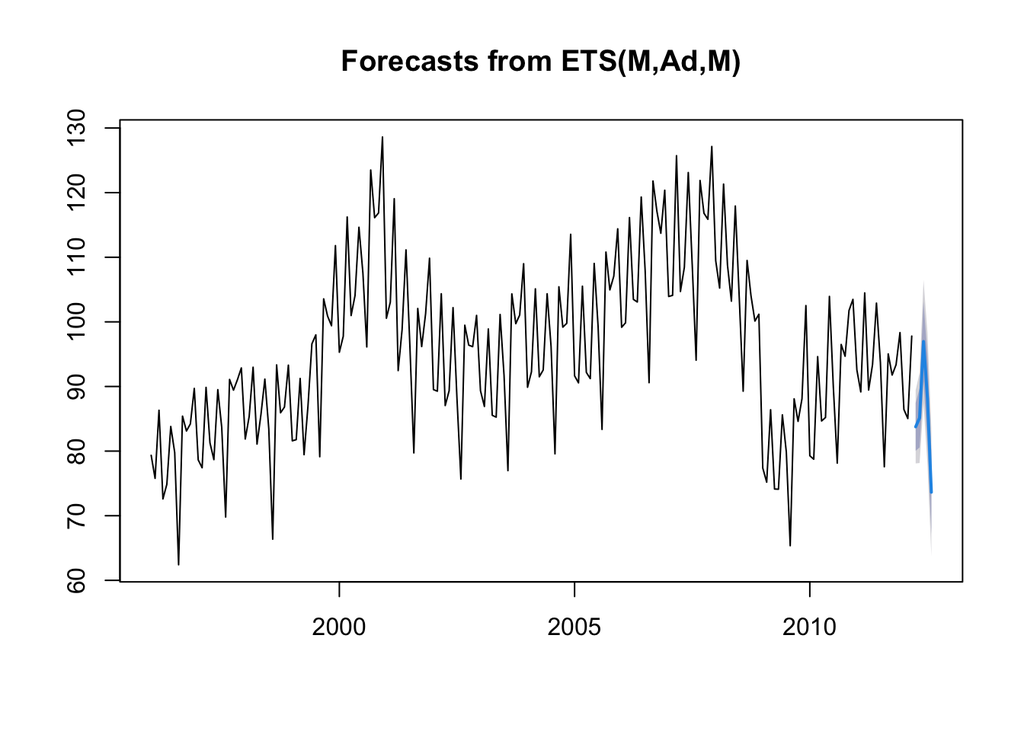

```r
#Forecast
forecast_ets_1 <- forecast.ets(ets_forecast, h=5)
plot(forecast_ets_1)
forecast_ets_2 <- forecast(ets_forecast, h=5)
plot(forecast_ets_2)
```